# **A Simple Python Notebook for Exploratory Analysis on the ANES Cumulative Time Series Data**

*Class project created by Catherine Gao*

# 1. Introduction

The *American National Election Studies* (ANES) produces high-quality data from surveying on voting, public opinion, and political participation in the U.S. on the national scale. The organization has started to collect responses from responderts both before and after each presidential election since 1948. The goal of ANES is to understand the political behaviors of the U.S. population, and its data has been widely used by various medias including election campaigns and political researches.

The dataset ANES Time Series Cumulative Data File used in this project can be accessed at ANES's [website](https://electionstudies.org/data-center/anes-time-series-cumulative-data-file/). This dataset includes survey responses from questions that have been asked in three or more ANES Time Series studies since 1948, with each variable incorporating data for the same question from each ANES survey over time.

One thing to keep in mind when using the Time Series Cumulative Data File is that all pooled cross-section samples should be analyzed with the weight variable to adjust for changes over time. The Basic Summary of Raw Data section will explain the effect of the weight variable in more detail.

This project primarily focuses on the political behavior of young voters who are between the age of 17 to 24. In particular, we will explore if there is an increasing rate of young people participating in election voting and what is the profile of those who vote. The ultimate goal is to understand how to attract more young people to vote in elections.

# 2. Import the ANES Raw Data

Not all questions are asked in every survey, therefore the graph "Fractions of Missing Values by Variables" indicates there is a significant amount of variables with over 80% missing values. Most of these variables involve questions that have been added to accout for the changes in the political landscape over time. Since this project mainly examines the demographic data that are part of the standard questions, variables with significant missing values should not have a matereiral impact on the analysis.

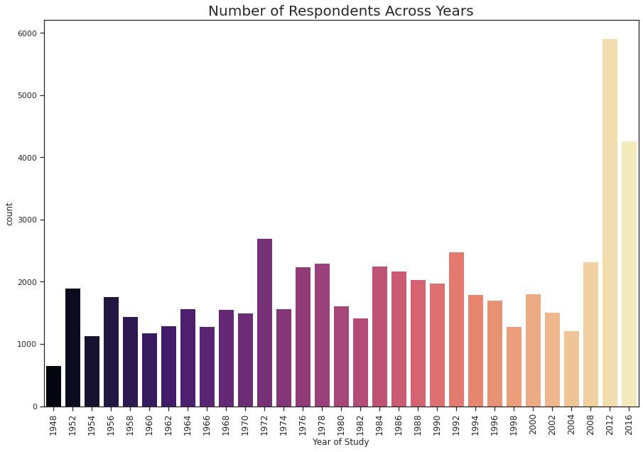

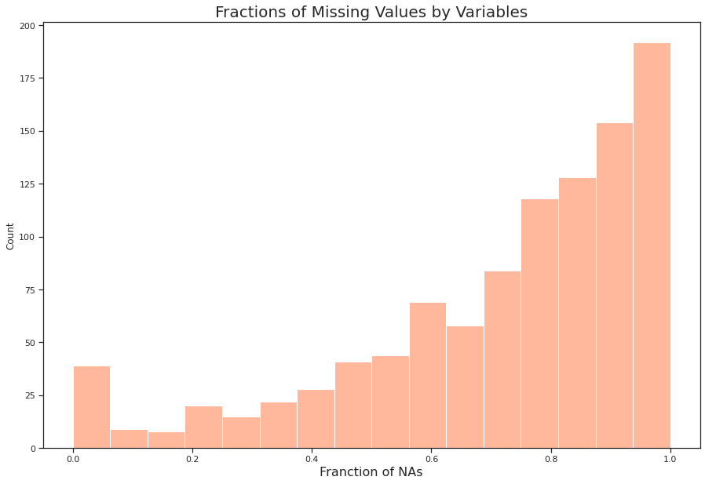

# 3. Process Data for Analysis

Since we want to focus on young voters who are between the age of 17 to 24, our main variable of interest would be VCF0102, which indicates the Age Groups in the data. In addition, we want to focus on how young voters are engaged on election day. Since election happens every 4 years, we will create a list of election years between 1952 and 2016.

Based on the codebook, the cross-sectional data from these years should be weighted during evaluation if we include data from 2012 and beyond: 1958, 1960, 1970, 1974, and 1976. Since we are going to use combined sample for 2012, we will use weight variable "VCF0009z" in all subsequent analyses.

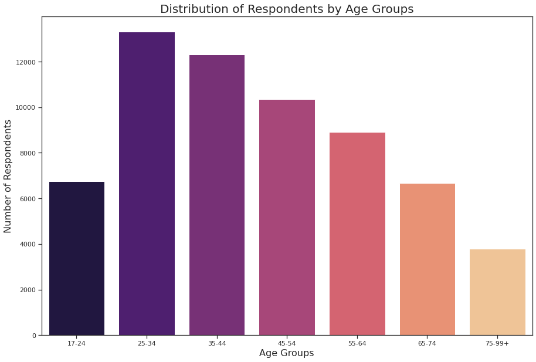

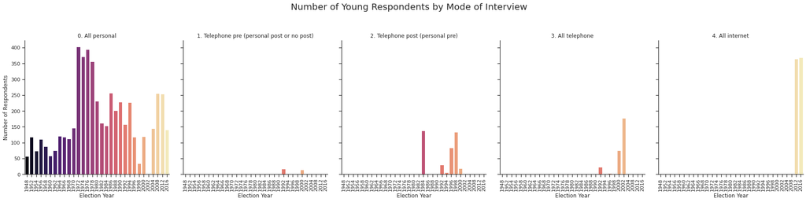

# 4. A Simple Analysis

### 4.1 Basic Profile of Age Group "17-24"

We first subset the dataset to include only respondents from age group "17-24" and results collected during election years. The subset includes a total of 3,563 rows and 1,029 variables.

"Number of Respondents Who Voted (Registered)" provides more context on the sample population. California has the most young respondents, but barely over 50% of the sample voted. The same situation applies to Texas and New York, which contain the second and third most respondents but only half of the samples voted.

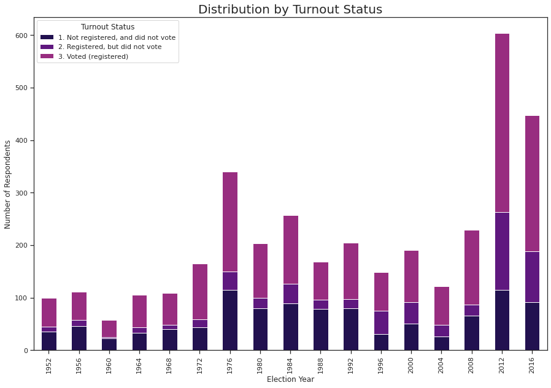

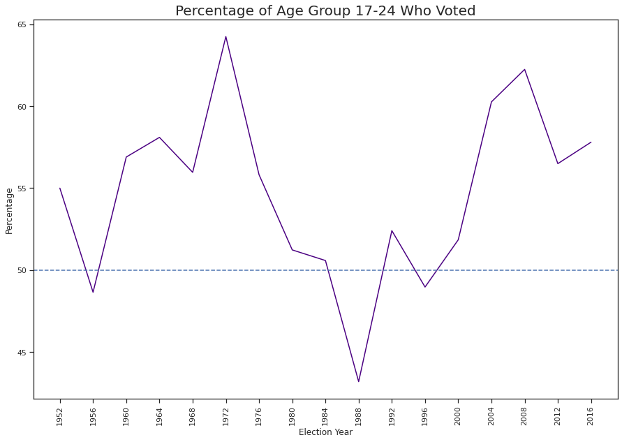

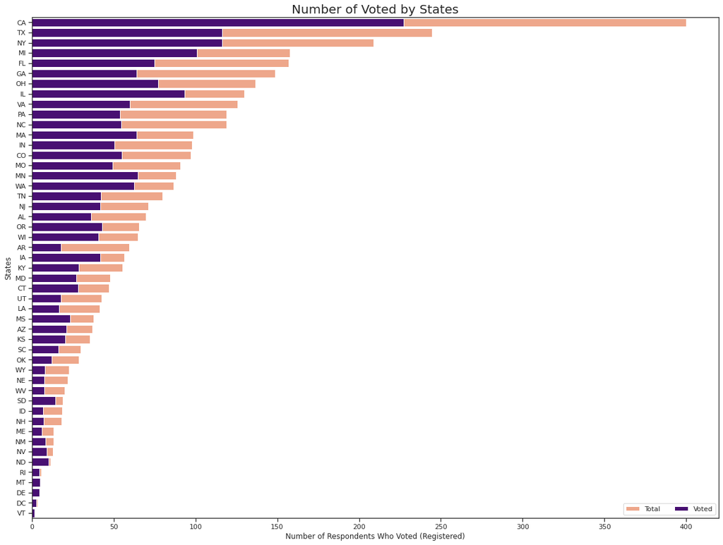

### 4.2 Young Respondents Who Voted

We want to further understand the young respondents who voted during election years. The first component we will explore is gender. For simplicity, we will exclude the 1 data point that falls under the "Other" category in variable VCF0104 [Gender].

Also, our prior analysis shows that the number of young respondents has surged with the internet survey, thus we will perform all of our subsequent analyses by comparing proportions to mitigate the misleading effect from the increase in quantity.

People usually think that males are more involved in politics than females. However, a recent study done by Pew Research Center shows that historically women have had higher rates of voter turnout than men (shown below).

[figure not shown]

While the result from our analysis aligns with the result from Pew's research that women have higher percentage of voter turnout, there is a change in the situation for election years after 2000 when the pertange of young male voters is higher than young female voters. More importantly, the gender gap is getting smaller in recent years as shown in the graph "Percentage of Voted by Gender Aross Years".

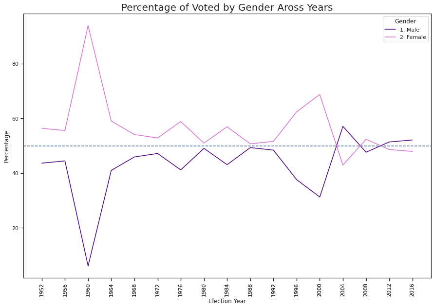

### 4.3 Are There Major Differences Among Young Voters Between the Genders?

##### by Education

Across years, we see a downward trend in female voters with a high school degree and an upward trend in female voters with some college. For male voters, however, the trends in these two categories fluctuate across years and remain stable on the average.

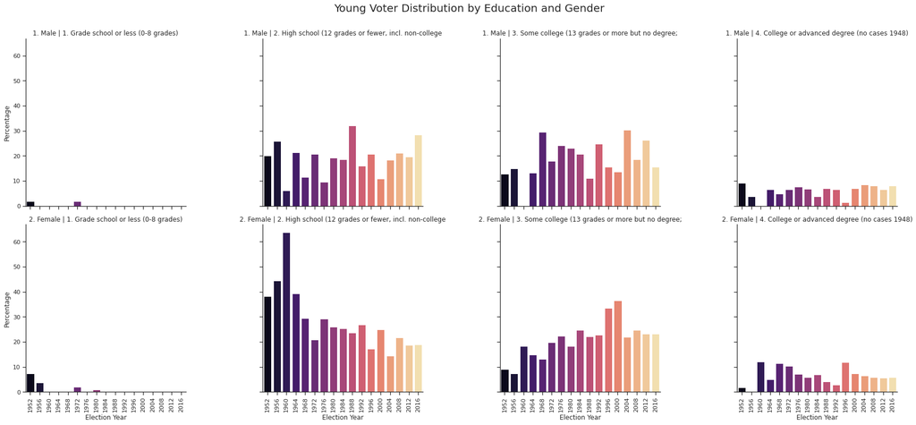

##### by Income Group

In 1950s, a large percentage of young voters (both male and female) are from the 34 to 95 income percentile. After 1990s, there is a shift of the percentage to the "0 to 16 percentile" as there is an upward trend for both genders. We also need to keep in mind the low percentage for the "96-100 percentile". One reason is that by nature, the population that fall under this category is fairly small.

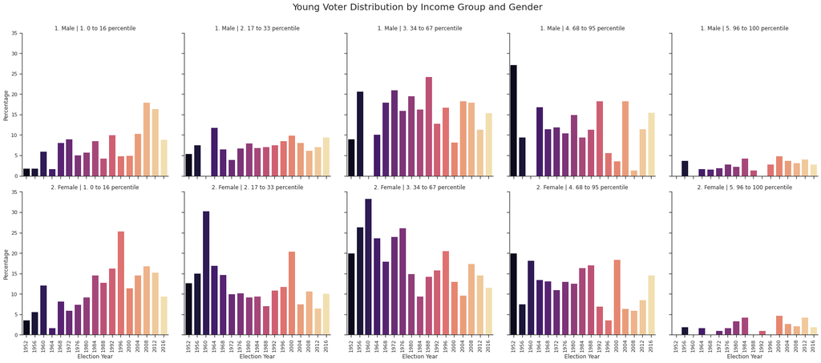

##### by Race

The "white non-hispanic" ethnicity group continues to hold the majority of young respondents who voted in election years. However, data shows there is growing participation from "Black non-Hispanic" and "Hispanic) in recent years for both genders. Particularly within the "Black non-Hispanic" group, the growth of young female voters is greater than that of young male voters. However, we should also consider non-response biases from difference race groups. A great proportion of these interviewed are conducted in person, and race groups other than White might be less acceptant to participate in these interviews. As a result, not much data from thess race groups have been captured.

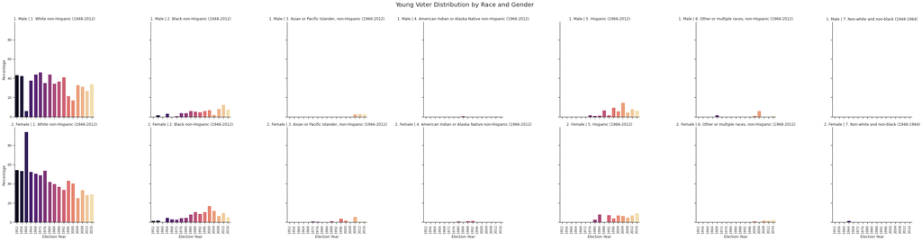

##### by Marital Status

Both the male and female voters show a decreasing percentage in the "Married" category and increasing percentage in the "Never Married" category. However, we should be mindful when interpreting this result due to confounding factors. While it could possibly mean that less young married respondents are likely to vote, it could also mean that people are getting married at a later age these days, and therefore a high percentage of voters are shifted from the "Married" to "Never Married" category.

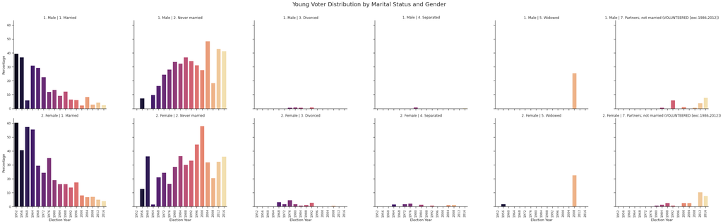

# 5. Conclusion